# ProjectB

Erik

2025-10-08

Balanserad data?

```r
df <- read.csv("B5_apple.csv")
# Data utskrift med alla tomma y
library(DT)
DT::datatable(df,
  options = list(
    pageLength = 50,
    lengthMenu = list(c(10, 25, 50, nrow(df)), c("10", "25", "50", "All")),
    scrollX = TRUE
  )
)
```

|  | bedomare | lagringstid | mognadstid | syre | y |
| --- | --- | --- | --- | --- | --- |
| 1 | 1 | 109 | 2 | 1 | 0.5 |
| 2 | 1 | 109 | 2 | 2 | 0.5 |
| 3 | 1 | 109 | 2 | 4 | 2 |
| 4 | 1 | 109 | 2 | 21 | 3 |
| 5 | 1 | 109 | 5 | 1 | 0.5 |
| 6 | 1 | 109 | 5 | 2 | 1 |
| 7 | 1 | 109 | 5 | 4 | 3 |
| 8 | 1 | 109 | 5 | 21 | 3 |
| 9 | 1 | 109 | 9 | 1 | 1.5 |
| 10 | 1 | 109 | 9 | 2 | 0.5 |

[output cut: 374 more lines]

```r
# Gör om blank till NA
df$y[df$y == ""] <- NA

# Säkerhetsåtgärd
df$y <- as.numeric(df$y)

# Tar bort rader med NA
df <- df[!is.na(df$y), ]

# Konvertera till faktorer (Viktigt för ANOVA)
df$bedomare <- factor(df$bedomare)
df$lagringstid <- factor(df$lagringstid)
df$mognadstid <- factor(df$mognadstid)
df$syre <- factor(df$syre)
df$syre <- relevel(df$syre, ref = "21")

# Beräknar medel (ny data för analys 1)
medel <- aggregate(y ~ lagringstid + mognadstid + syre, data = df, FUN = mean)
# Visar datan men borttagna y
library(DT)
DT::datatable(df,
  options = list(
    pageLength = 50,
    lengthMenu = list(c(10, 25, 50, nrow(df)), c("10", "25", "50", "All")),
    scrollX = TRUE
  )
)
```

|  | bedomare | lagringstid | mognadstid | syre | y |
| --- | --- | --- | --- | --- | --- |
| 1 | 1 | 109 | 2 | 1 | 0.5 |
| 2 | 1 | 109 | 2 | 2 | 0.5 |
| 3 | 1 | 109 | 2 | 4 | 2 |
| 4 | 1 | 109 | 2 | 21 | 3 |
| 5 | 1 | 109 | 5 | 1 | 0.5 |
| 6 | 1 | 109 | 5 | 2 | 1 |
| 7 | 1 | 109 | 5 | 4 | 3 |
| 8 | 1 | 109 | 5 | 21 | 3 |
| 9 | 1 | 109 | 9 | 1 | 1.5 |
| 10 | 1 | 109 | 9 | 2 | 0.5 |

[output cut: 326 more lines]

```r
modell1 <- aov(y ~lagringstid * mognadstid * syre, data = medel)
anova(modell1)
```

```
## Analysis of Variance Table
##
## Response: y
##                             Df Sum Sq Mean Sq F value Pr(>F)
## lagringstid                  1 0.0786 0.07864     NaN    NaN
## mognadstid                   5 1.4476 0.28952     NaN    NaN
## syre                         3 7.6852 2.56174     NaN    NaN
## lagringstid:mognadstid       5 0.4973 0.09945     NaN    NaN
## lagringstid:syre             3 2.1371 0.71236     NaN    NaN
## mognadstid:syre             15 6.7943 0.45295     NaN    NaN
## lagringstid:mognadstid:syre 15 5.0649 0.33766     NaN    NaN
## Residuals                    0 0.0000     NaN
```

Problem, saknas y värden i vissa data points.  
Ej balanserad då?  
Inga frihetsgrader kvar för residualer => inga F-test möjligt.

**Analys 1**

```r
# Inget trevägssamspel
fit_no3 <- aov(y ~ (lagringstid * mognadstid) +
                      (lagringstid * syre) +
                      (mognadstid * syre),
               data = medel)
anova(fit_no3)
```

```
## Analysis of Variance Table
##
## Response: y
##                        Df Sum Sq Mean Sq F value   Pr(>F)
## lagringstid             1 0.0786 0.07864  0.2329 0.636354
## mognadstid              5 1.4476 0.28952  0.8574 0.531334
## syre                    3 7.6852 2.56174  7.5867 0.002569 **
## lagringstid:mognadstid  5 0.4973 0.09945  0.2945 0.908505
## lagringstid:syre        3 2.1371 0.71236  2.1097 0.141877
## mognadstid:syre        15 6.7943 0.45295  1.3414 0.288271
## Residuals              15 5.0649 0.33766
## ---
## Signif. codes:  0 '***' 0.001 '**' 0.01 '*' 0.05 '.' 0.1 ' ' 1
```

```r
anova(fit_no3, modell1)
```

```
## Analysis of Variance Table
##
## Model 1: y ~ (lagringstid * mognadstid) + (lagringstid * syre) + (mognadstid *
##     syre)
## Model 2: y ~ lagringstid * mognadstid * syre
##   Res.Df    RSS Df Sum of Sq   F Pr(>F)
## 1     15 5.0649
## 2      0 0.0000 15    5.0649 NaN    NaN
```

Nu har vi frihetsgrader över och noterar att syre är signifikant för smakpreferens. Samspelet av lagringstid och syre närmast att vara signifikant. Lagringstid och mognadstid helt insignifikant.

```
## NOTE: syre is not a high-order term in the model
```

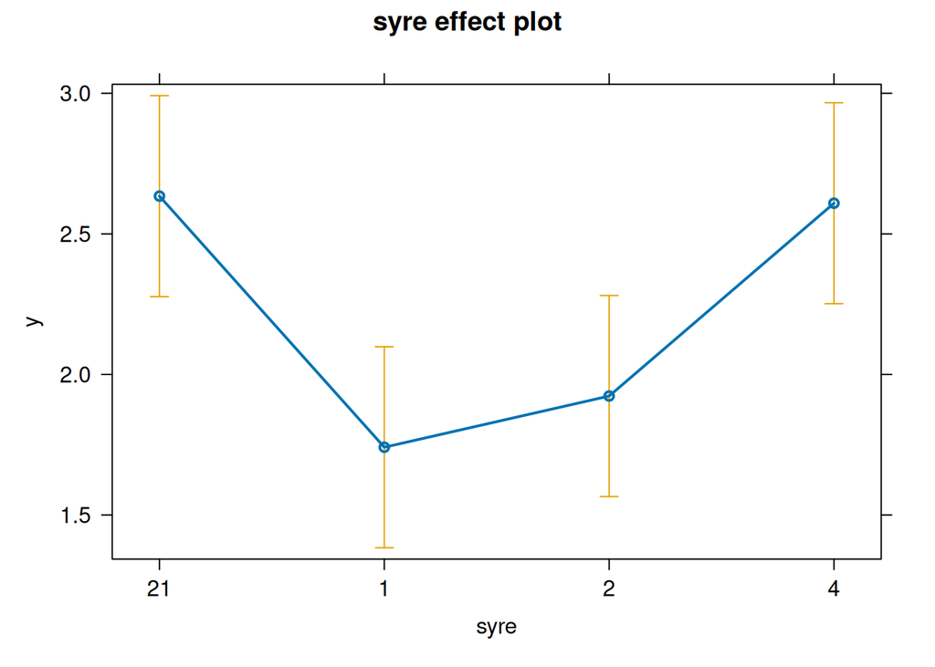

```r
# Effektplot, bör framförallt jämföra samspel
library(effects)
plot(effect("syre", fit_no3), multiline = TRUE)
```

```r
# Skattningar för analys 1 (inget trevägssamspel)
modell_lm <- lm(fit_no3)
summary(modell_lm)
```

```
##
## Call:
## lm(formula = fit_no3)
##
## Residuals:
##     Min      1Q  Median      3Q     Max
## -0.8176 -0.1717  0.0000  0.1717  0.8176
##
## Coefficients:
##                             Estimate Std. Error t value Pr(>|t|)
## (Intercept)                  3.13542    0.48181   6.508  9.9e-06 ***
## lagringstid190              -0.04762    0.50324  -0.095  0.92586
## mognadstid5                 -0.24554    0.64968  -0.378  0.71077
## mognadstid9                 -0.13750    0.64968  -0.212  0.83523
## mognadstid12                -0.61719    0.64968  -0.950  0.35717
## mognadstid19                -0.68973    0.64968  -1.062  0.30519
## mognadstid26                -0.91719    0.64968  -1.412  0.17843
## syre1                       -1.57778    0.62765  -2.514  0.02385 *
## syre2                       -2.13586    0.62765  -3.403  0.00393 **
## syre4                       -0.70303    0.62765  -1.120  0.28029
## lagringstid190:mognadstid5   0.18750    0.58109   0.323  0.75140
## lagringstid190:mognadstid9  -0.19821    0.58109  -0.341  0.73775
## lagringstid190:mognadstid12 -0.05134    0.58109  -0.088  0.93077
## lagringstid190:mognadstid19  0.01339    0.58109   0.023  0.98192
## lagringstid190:mognadstid26 -0.46384    0.58109  -0.798  0.43720
## lagringstid190:syre1        -0.61230    0.47446  -1.291  0.21640
## lagringstid190:syre2         0.33423    0.47446   0.704  0.49195
## lagringstid190:syre4         0.48641    0.47446   1.025  0.32152
## mognadstid5:syre1            0.12054    0.82178   0.147  0.88534
## mognadstid9:syre1            1.26518    0.82178   1.540  0.14450
## mognadstid12:syre1           1.48810    0.82178   1.811  0.09024 .
## mognadstid19:syre1           1.84821    0.82178   2.249  0.03996 *
## mognadstid26:syre1           1.22143    0.82178   1.486  0.15791
## mognadstid5:syre2            0.59821    0.82178   0.728  0.47786
## mognadstid9:syre2            1.04375    0.82178   1.270  0.22340
## mognadstid12:syre2           1.84375    0.82178   2.244  0.04038 *
## mognadstid19:syre2           1.64732    0.82178   2.005  0.06341 .
## mognadstid26:syre2           2.41250    0.82178   2.936  0.01023 *
## mognadstid5:syre4            0.51339    0.82178   0.625  0.54153
## mognadstid9:syre4            0.51607    0.82178   0.628  0.53945
## mognadstid12:syre4           0.44940    0.82178   0.547  0.59251
## mognadstid19:syre4           0.28125    0.82178   0.342  0.73692
## mognadstid26:syre4           0.84732    0.82178   1.031  0.31884
## ---
## Signif. codes:  0 '***' 0.001 '**' 0.01 '*' 0.05 '.' 0.1 ' ' 1
##
## Residual standard error: 0.5811 on 15 degrees of freedom
## Multiple R-squared:  0.7863, Adjusted R-squared:  0.3305
## F-statistic: 1.725 on 32 and 15 DF,  p-value: 0.1313
```

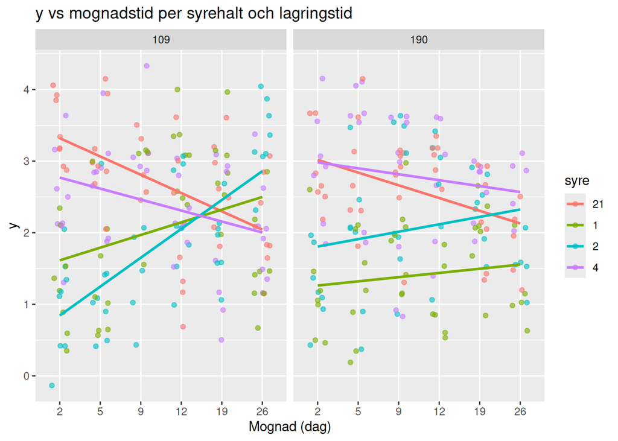

```r
#Punkt + linjär trend över mognadstid per syre
library(ggplot2)
ggplot(df, aes(x = mognadstid, y = y, group = syre, color = syre)) +
  geom_point(position = position_jitter(width = 0.2), alpha = 0.6) +
  geom_smooth(method = "lm", se = FALSE) +
  facet_wrap(~ lagringstid) +
  labs(title = "y vs mognadstid per syrehalt och lagringstid", x = "Mognad (dag)", y = "y")
```

Ser bra nog ut, kan motiver mer med shapiro test mm. för att visa att modell antaganden uppfylda.

**Analys 2**

```r
library(lme4)
library(lmerTest)
```

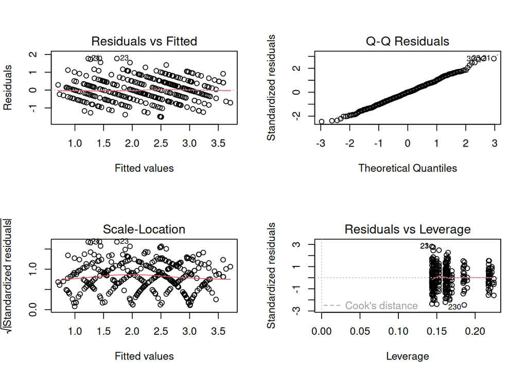

```r
#full modell typ 1
fit_full <- aov(y ~ bedomare + lagringstid * mognadstid * syre, data = df)

par(mfrow = c(2,2))
plot(fit_full)  # Residuals vs fitted, Q-Q, Scale-Location, Cook's/Leverage
```

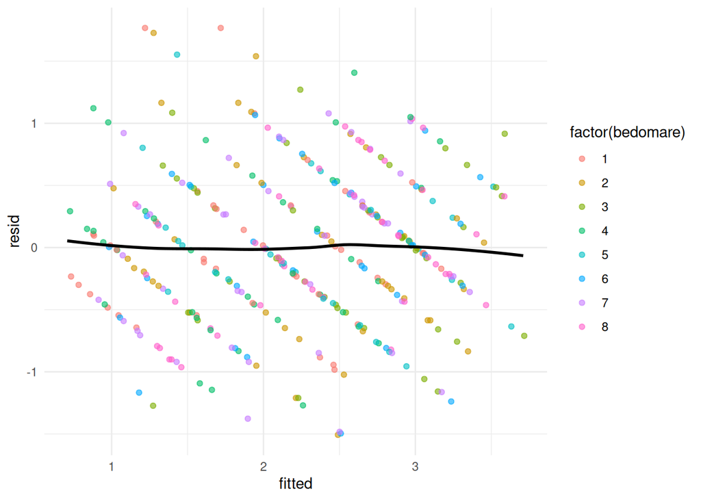

```r
par(mfrow = c(1,1))

library(ggplot2)
df$resid <- residuals(fit_full)
df$fitted <- fitted(fit_full)
ggplot(df, aes(x = fitted, y = resid, color = factor(bedomare))) +
  geom_jitter(width = 0.02, height = 0, alpha = 0.6) +
  geom_smooth(method = "loess", se = FALSE, color = "black") +
  theme_minimal()
```

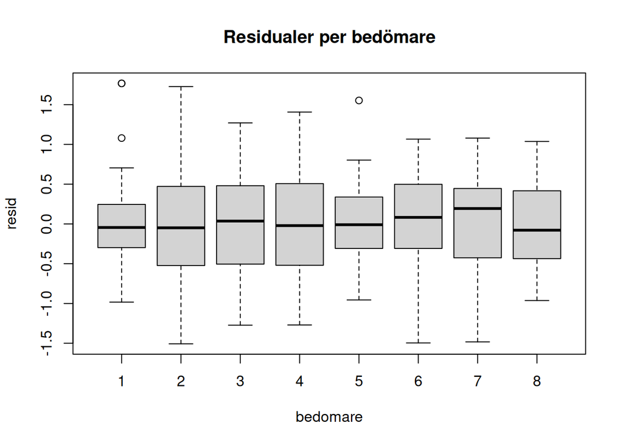

```r
boxplot(resid ~ bedomare, data = df, main = "Residualer per bedömare")
```

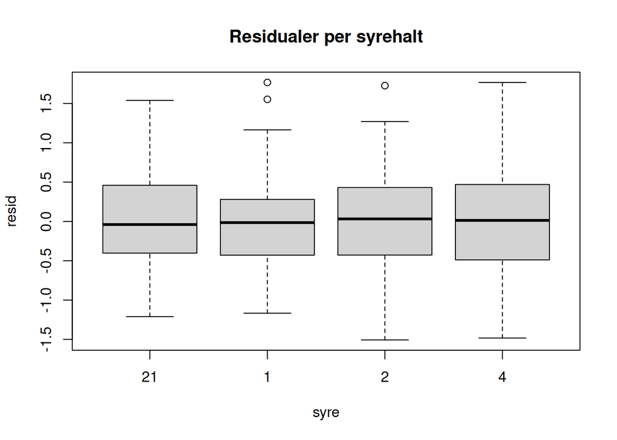

```r
boxplot(resid ~ syre, data = df, main = "Residualer per syrehalt")
```

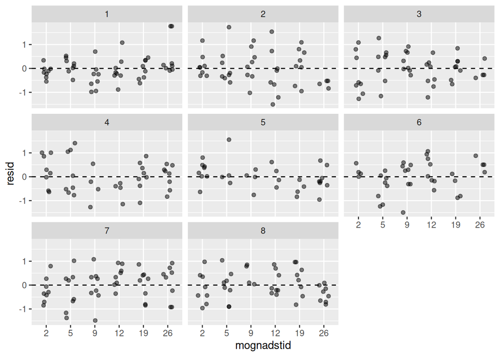

```r
# Vald för att mognadstid och residualer visar troligen
# bäst om det finns systematiska avvikelser.
ggplot(df, aes(x = mognadstid, y = resid)) +
  geom_jitter(width = 0.2, height = 0, alpha = 0.5) +
  facet_wrap(~ bedomare) + geom_hline(yintercept = 0, linetype = 2)
```

```r
cooks <- cooks.distance(fit_full)
lev <- hatvalues(fit_full)
thr <- 4/(nrow(df)-length(coef(fit_full)))
which(cooks > thr)       # indices med Cook's > cutoff
```

```
##  21  23  30  40 101 230 246 272 319 322 342 347
##  21  23  30  40  97 214 226 248 279 282 294 299
```

```r
data.frame(row = which(cooks>thr), cooks = cooks[which(cooks>thr)], leverage = lev[which(cooks>thr)])
```

```
##     row      cooks  leverage
## 21   21 0.02411206 0.1437539
## 23   23 0.02411206 0.1437539
## 30   30 0.02337730 0.1453699
## 40   40 0.01857711 0.1453699
## 101  97 0.02022165 0.1528726
## 230 214 0.02505658 0.1857702
## 246 226 0.01473520 0.1626028
## 272 248 0.01840675 0.1647278
## 319 279 0.01451830 0.1668522
## 322 282 0.01828519 0.1499323
## 342 294 0.01709835 0.1611510
## 347 299 0.01697358 0.1437539
```

Alla modellantaganden verkar uppfylde, samt ser vi inga tydliga mönster för någon av bedömarna.

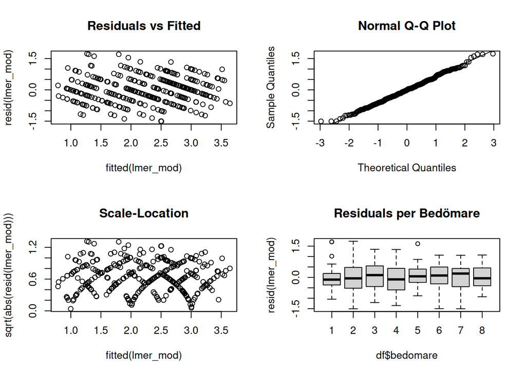

```r
#Blandad modell
lmer_mod <- lmer(y ~ lagringstid * mognadstid * syre + (1 | bedomare), data = df)

# --- Residualdiagnostik ---
par(mfrow=c(2,2))
plot(fitted(lmer_mod), resid(lmer_mod), main="Residuals vs Fitted")
qqnorm(resid(lmer_mod)); qqline(resid(lmer_mod))
plot(fitted(lmer_mod), sqrt(abs(resid(lmer_mod))), main="Scale-Location")
boxplot(resid(lmer_mod) ~ df$bedomare, main="Residuals per Bedömare")
```

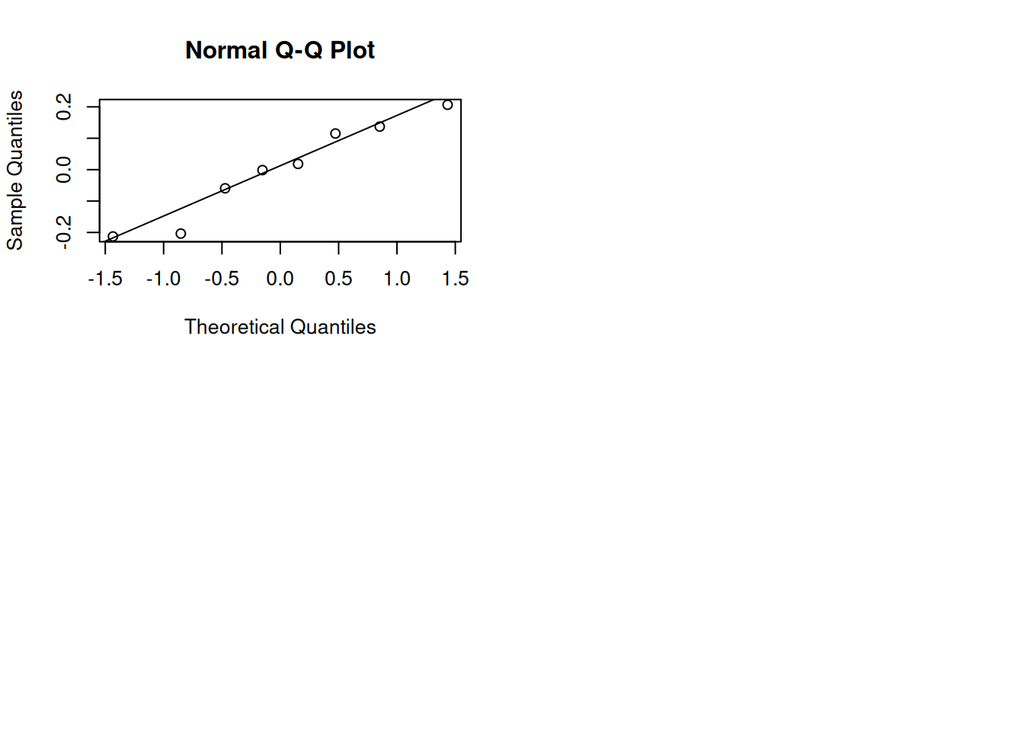

```r
# --- Random effects ---
qqnorm(ranef(lmer_mod)$bedomare[[1]]); qqline(ranef(lmer_mod)$bedomare[[1]])
```

```r
mod_sys <- lm(y ~ lagringstid * mognadstid * syre + bedomare, data = df)
mod_rand <- lmer(y ~ lagringstid * mognadstid * syre + (1 | bedomare), data = df)
# Testet använder Relative Likelihood test
anova(mod_rand, mod_sys)
```

```
## refitting model(s) with ML (instead of REML)
```

```
## Data: df
## Models:
## mod_rand: y ~ lagringstid * mognadstid * syre + (1 | bedomare)
## mod_sys: y ~ lagringstid * mognadstid * syre + bedomare
##          npar    AIC    BIC  logLik -2*log(L)  Chisq Df Pr(>Chisq)
## mod_rand   50 752.92 943.78 -326.46    652.92
## mod_sys    56 745.84 959.60 -316.92    633.84 19.084  6   0.004025 **
## ---
## Signif. codes:  0 '***' 0.001 '**' 0.01 '*' 0.05 '.' 0.1 ' ' 1
```

Det sista testet för jämförelse av modellerna gör ett likelihood ratio test: $\chi^2 = 2(l(\theta) - l(\hat \theta))$ eller mer specifkt $\chi^2 = -2(l_{enklare} - l_{slump)}$ (log-likelihood). Residualanalysen visar att bedömarna inte har tydliga mönster när vi analyserar den systematiska versionen, men samtidigt är det mycket sämre att ersätta dem med helt slumpade resultat.

Det betyder alltså att:

Modellen med bedömare som fasta effekter förklarar verkliga systematiska skillnader mellan bedömare.

De slumpmässiga effekterna är för grova, de kan inte fånga upp den struktur som finns i datan.

**Skattningar analys 2**

```r
fit_full_lm <- lm(y ~ bedomare + lagringstid * mognadstid * syre, data = df )
summary(fit_full_lm)
```

```
##
## Call:
## lm(formula = y ~ bedomare + lagringstid * mognadstid * syre,
##     data = df)
##
## Residuals:
##      Min       1Q   Median       3Q      Max
## -1.50700 -0.42301 -0.00786  0.42314  1.76725
##
## Coefficients:
##                                    Estimate Std. Error t value Pr(>|t|)
## (Intercept)                        3.170249   0.257644  12.305  < 2e-16 ***
## bedomare2                          0.290100   0.142454   2.036 0.042643 *
## bedomare3                          0.540100   0.142454   3.791 0.000183 ***
## bedomare4                         -0.025181   0.146708  -0.172 0.863846
## bedomare5                          0.464562   0.157658   2.947 0.003482 **
## bedomare6                          0.263306   0.151605   1.737 0.083520 .
## bedomare7                          0.187500   0.138709   1.352 0.177543
## bedomare8                          0.417618   0.142450   2.932 0.003649 **
## lagringstid190                    -0.652349   0.352026  -1.853 0.064912 .
## mognadstid5                       -0.375000   0.339767  -1.104 0.270668
## mognadstid9                       -0.426451   0.388606  -1.097 0.273412
## mognadstid12                      -1.500000   0.339767  -4.415 1.44e-05 ***
## mognadstid19                      -0.766456   0.352065  -2.177 0.030311 *
## mognadstid26                      -1.312500   0.339767  -3.863 0.000139 ***
## syre1                             -2.125000   0.339767  -6.254 1.48e-09 ***
## syre2                             -2.437500   0.339767  -7.174 6.48e-12 ***
## syre4                             -1.062500   0.339767  -3.127 0.001950 **
## lagringstid190:mognadstid5         0.475179   0.497967   0.954 0.340783
## lagringstid190:mognadstid9         0.391300   0.524020   0.747 0.455853
## lagringstid190:mognadstid12        1.698996   0.509277   3.336 0.000964 ***
## lagringstid190:mognadstid19        0.195027   0.505849   0.386 0.700126
## lagringstid190:mognadstid26        0.385700   0.523833   0.736 0.462160
## lagringstid190:syre1               0.482143   0.497368   0.969 0.333185
## lagringstid190:syre2               0.937500   0.497368   1.885 0.060472 .
## lagringstid190:syre4               1.205357   0.497368   2.423 0.016005 *
## mognadstid5:syre1                  0.312500   0.480503   0.650 0.515991
## mognadstid9:syre1                  1.825000   0.547857   3.331 0.000981 ***
## mognadstid12:syre1                 3.250000   0.480503   6.764 7.79e-11 ***
## mognadstid19:syre1                 2.339286   0.497368   4.703 4.02e-06 ***
```

[output cut: 17 more lines]

```
## lagringstid190:mognadstid9:syre2   0.412500   0.739947   0.557 0.577649
## lagringstid190:mognadstid12:syre2 -1.687500   0.718845  -2.348 0.019593 *
## lagringstid190:mognadstid19:syre2  0.133929   0.715011   0.187 0.851553
## lagringstid190:mognadstid26:syre2 -2.425000   0.739947  -3.277 0.001180 **
## lagringstid190:mognadstid5:syre4  -0.598214   0.703384  -0.850 0.395782
## lagringstid190:mognadstid9:syre4  -1.692857   0.739947  -2.288 0.022892 *
## lagringstid190:mognadstid12:syre4 -1.851190   0.718845  -2.575 0.010529 *
## lagringstid190:mognadstid19:syre4  0.008929   0.715011   0.012 0.990046
## lagringstid190:mognadstid26:syre4 -0.180357   0.739947  -0.244 0.807608
## ---
## Signif. codes:  0 '***' 0.001 '**' 0.01 '*' 0.05 '.' 0.1 ' ' 1
##
## Residual standard error: 0.6795 on 281 degrees of freedom
## Multiple R-squared:  0.5764, Adjusted R-squared:  0.495
## F-statistic: 7.081 on 54 and 281 DF,  p-value: < 2.2e-16
```

```r
anova(fit_full)
```

```
## Analysis of Variance Table
##
## Response: y
##                              Df  Sum Sq Mean Sq F value    Pr(>F)
## bedomare                      7  13.789  1.9698  4.2658 0.0001691 ***
## lagringstid                   1   0.049  0.0495  0.1071 0.7437097
## mognadstid                    5   7.662  1.5323  3.3184 0.0062795 **
## syre                          3  51.044 17.0146 36.8469 < 2.2e-16 ***
## lagringstid:mognadstid        5   2.884  0.5768  1.2491 0.2863288
## lagringstid:syre              3  13.268  4.4225  9.5774 4.843e-06 ***
## mognadstid:syre              15  54.854  3.6569  7.9194 7.426e-15 ***
## lagringstid:mognadstid:syre  15  33.028  2.2018  4.7683 3.203e-08 ***
## Residuals                   281 129.756  0.4618
## ---
## Signif. codes:  0 '***' 0.001 '**' 0.01 '*' 0.05 '.' 0.1 ' ' 1
```

Både mognadstid och syrehalt påverkar smaken kraftigt.

Effekterna av syre beror på både mognadstid och lagringstid, så komplex samverkan mellan dessa faktorer.